# SES5215_Lzhang_FinalExam

Lamei Zhang

12/3/2021

## Loading packages

```r
library(tidyverse)
library(knitr)
library(sf)
library(interactions)
```

## Loading data

```r
main_st_data <- read_csv("exam_data_lamei_zhang.csv")
```

## Question 1: What was the average change in sales for Main St businesses?

To solve this question, I used a t-test on the percent in sales change(“pct_sales_chng”) on the 420 businesses that exist on Main Street. This allowed me to determine the average rate of increase or decrease for all businesses on Main Street, the confidence interval, and the confidence level of this analysis.

```r
t.test(main_st_data$pct_sales_chng)
```

```
##
##  One Sample t-test
##
## data:  main_st_data$pct_sales_chng
## t = 14.161, df = 419, p-value < 2.2e-16
## alternative hypothesis: true mean is not equal to 0
## 95 percent confidence interval:
##  0.02224900 0.02942136
## sample estimates:
##  mean of x
## 0.02583518
```

From the t-test, I saw that on average there was a 2.5 percent increase in sales among all businesses on Main Street from March to October. The 95 percent confidence interval for this increase was 2.22 percent to 2.94 percent. The p-value was less than 0.01 which would means I am more than 99.9 percent certain that sales have increased on Main Street.

## Question 2: Did the cost of parking change more for some types of businesses than for others? How confident are you about those differences?

In addition to redesigning twenty blocks of Main Street, the city of Townsville also increased the hourly rate of metered parking along several blocks on the south side of the street.

To assess the impact of this change on businesses, I identified the types of businesses that exist on Main Street and ran a bivariate regression, holding one type of business as my base case.

Before running my regression, I determined the kinds of stores on Main Street.

```r
main_st_data %>%
  group_by(type) %>%
  summarise(number = n()) %>%
  mutate(percent = round(100*number/sum(number))) %>%
  arrange(desc(number))
```

```
## # A tibble: 7 x 3
##   type        number percent
##   <chr>        <int>   <dbl>
## 1 Grocery        104      25
## 2 Drugstore       96      23
## 3 Restaurant      70      17
## 4 Clothing        60      14
## 5 Furniture       56      13
## 6 Books           26       6
## 7 Gas station      8       2
```

By grouping the businesses by type and calculating the number of stores per type, I determined that GROCERY businesses were the most common type of store on Main Street. I selected GROCERY businesses as my base case due their proliferation.

From there, I used the ‘relevel’ function to hold GROCERY type businesses as the base case to which all other comparisons regarding business type will be made against it.

```r
main_st_data <- main_st_data %>%
  mutate(type = as.factor(type)) %>%
  mutate(type = relevel(type, "Grocery"))
```

```r
parking_cost_by_type <- lm(parking_cost_change ~ type, data = main_st_data)

summary(parking_cost_by_type)
```

```
##
## Call:
## lm(formula = parking_cost_change ~ type, data = main_st_data)
##
## Residuals:
##       Min        1Q    Median        3Q       Max
## -0.125010 -0.029469  0.000527  0.029990  0.131050
##
## Coefficients:
##                  Estimate Std. Error t value Pr(>|t|)
## (Intercept)      0.046288   0.004312  10.736  < 2e-16 ***
## typeBooks        0.073135   0.009641   7.586 2.21e-13 ***
## typeClothing     0.027662   0.007128   3.881 0.000121 ***
## typeDrugstore    0.089722   0.006223  14.417  < 2e-16 ***
## typeFurniture    0.014194   0.007288   1.948 0.052142 .
## typeGas station -0.033413   0.016132  -2.071 0.038959 *
## typeRestaurant   0.107369   0.006798  15.795  < 2e-16 ***
## ---
## Signif. codes:  0 '***' 0.001 '**' 0.01 '*' 0.05 '.' 0.1 ' ' 1
##
## Residual standard error: 0.04397 on 413 degrees of freedom
## Multiple R-squared:  0.5041, Adjusted R-squared:  0.4969
## F-statistic: 69.98 on 6 and 413 DF,  p-value: < 2.2e-16
```

The business types that saw the greatest increases in parking costs were RESTAURANTS, which had 10.7 percentage points more of an increase compared to GROCERY businesses, and DRUGSTORE type businesses, which had 8.9 percentage points more of an increase compared to GROCERY businesses.

BOOK and CLOTHING type businesses exhibited slightly lesser increases in parking costs compared to RESTAURANTS and DRUGSTORE type businesses, but still saw higher parking cost increases than GROCERY type businesses. BOOK type businesses showed 7.3 percentage points more of an increase compared to GROCERY types, and CLOTHING type businesses showed 2.7 percentage points more of an increase compared to GROCERY types.

The business that saw the least amount of change to parking costs were GAS STATION type businesses. These businesses saw 3.3 percentage points less of an increase in parking costs compared to GROCERY type businesses.

From the regression, I am at least 95 percent confident that GROCERY, BOOK, CLOTHING, DRUGSTORE, GAS STATION and RESTAURANT type businesses had significant changes in their parking costs.

## Question 3: Not counting any kind of effect of the changes to parking and cycling have had, what kind of effect did it have on businesses if the closest transit stop got closer or further away?

The Main Street redesign included the introduction of a streetcar line which replaced a bus line and changed the location of transit stops. Considering the change in transit stops, this question asks if there was an effect of the new distance of transit stops on businesses, without taking into consideration the changes to parking and cycling.

For the purpose of determining this effect, I compared the percent change in business sales and the distance a business is to a transit stop. I ran a regression and controlled for changes in parking supply, changes in parking prices, and changes in bike traffic.

```r
model_1 <- lm(pct_sales_chng ~ transit_dist + lost_parking +  parking_cost_change + bike_chng, data = main_st_data)

summary(model_1)
```

```
##
## Call:
## lm(formula = pct_sales_chng ~ transit_dist + lost_parking + parking_cost_change +
##     bike_chng, data = main_st_data)
##
## Residuals:
##       Min        1Q    Median        3Q       Max
## -0.065003 -0.023447 -0.006847  0.022802  0.098432
##
## Coefficients:
##                       Estimate Std. Error t value Pr(>|t|)
## (Intercept)          0.0192414  0.0042227   4.557 6.84e-06 ***
## transit_dist        -0.1896993  0.0266858  -7.109 5.15e-12 ***
## lost_parking        -0.0011501  0.0008018  -1.434   0.1522
## parking_cost_change  0.2442436  0.0272169   8.974  < 2e-16 ***
## bike_chng            0.0683103  0.0313896   2.176   0.0301 *
## ---
## Signif. codes:  0 '***' 0.001 '**' 0.01 '*' 0.05 '.' 0.1 ' ' 1
##
## Residual standard error: 0.03148 on 415 degrees of freedom
## Multiple R-squared:  0.2981, Adjusted R-squared:  0.2913
## F-statistic: 44.07 on 4 and 415 DF,  p-value: < 2.2e-16
```

Based on this regression, it can be determined that there was an inverse relationship between the distance a business was to the nearest transit stop and change in sales for that business. In this case, a mile increase in transit distance equated to about a 18.9 percentage point drop in business sales.

## Question 4: Was the effect of transit on sales different for some types of businesses than for others? What was the difference, if any?

Continuing the analysis on distance to transit with business sales, this questions asks if there were any significant differences between business types, their distance to transit, and their business sales. For the purposes of consistency, I used the same model from Question 3, controlling for cycling and parking changes.

```r
model_2 <- lm(pct_sales_chng ~ type + transit_dist + parking_cost_change + lost_parking + bike_chng + type:transit_dist, data = main_st_data)

summary(model_2)
```

```
##
## Call:
## lm(formula = pct_sales_chng ~ type + transit_dist + parking_cost_change +
##     lost_parking + bike_chng + type:transit_dist, data = main_st_data)
##
## Residuals:
##       Min        1Q    Median        3Q       Max
## -0.069966 -0.009283 -0.000248  0.008731  0.054637
##
## Coefficients:
##                                Estimate Std. Error t value Pr(>|t|)
## (Intercept)                  -0.0086809  0.0037756  -2.299  0.02200 *
## typeBooks                     0.0727257  0.0072644  10.011  < 2e-16 ***
## typeClothing                  0.0909187  0.0056268  16.158  < 2e-16 ***
## typeDrugstore                 0.0906238  0.0057818  15.674  < 2e-16 ***
## typeFurniture                 0.0023111  0.0059919   0.386  0.69992
## typeGas station               0.0093458  0.0126838   0.737  0.46165
## typeRestaurant                0.0936672  0.0059454  15.755  < 2e-16 ***
## transit_dist                  0.0001072  0.0309073   0.003  0.99723
## parking_cost_change          -0.0251123  0.0225537  -1.113  0.26618
## lost_parking                 -0.0012861  0.0004805  -2.676  0.00774 **
## bike_chng                     0.0556600  0.0189978   2.930  0.00358 **
## typeBooks:transit_dist       -0.1607435  0.0743215  -2.163  0.03114 *
## typeClothing:transit_dist    -0.3103575  0.0531937  -5.834 1.11e-08 ***
## typeDrugstore:transit_dist   -0.3305778  0.0473870  -6.976 1.25e-11 ***
## typeFurniture:transit_dist   -0.0117092  0.0536346  -0.218  0.82729
## typeGas station:transit_dist -0.0023615  0.1246092  -0.019  0.98489
## typeRestaurant:transit_dist  -0.3409236  0.0494107  -6.900 2.03e-11 ***
## ---
## Signif. codes:  0 '***' 0.001 '**' 0.01 '*' 0.05 '.' 0.1 ' ' 1
##
## Residual standard error: 0.01881 on 403 degrees of freedom
## Multiple R-squared:  0.7565, Adjusted R-squared:  0.7468
## F-statistic: 78.25 on 16 and 403 DF,  p-value: < 2.2e-16
```

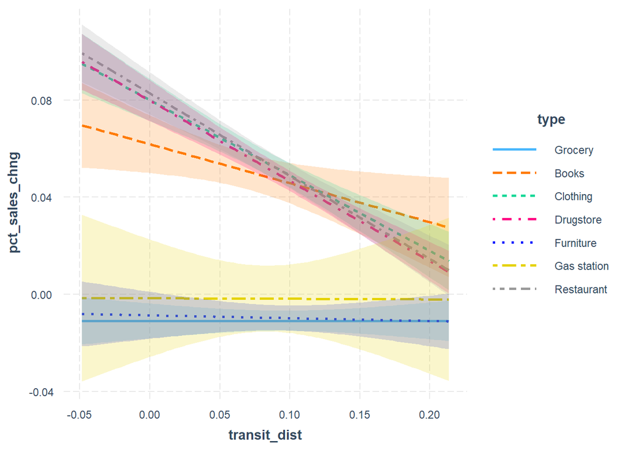

```r
interact_plot(model_2, pred = transit_dist, interval = TRUE, modx = type)
```

My base case, the impact transit distance has on GROCERY business sales, showed a 0.01 percentage point sales increase with each additional mile from a transit stop. However, this data was not statistically significant at the 95 percent confidence level.

Comparing other business types to GROCERY businesses, it could be seen that there are statistically significant results at the 95 percent confidence level for BOOK, CLOTHING, DRUGSTORE, and RESTAURANT type businesses. Regression of GROCERY, GAS STATION, and FURNITURE type businesses did not prove to be statistically significant at the 95 percent confidence level.

With the use of an interaction model, the interaction transit distance has on specific types of businesses’ sales can be described as having a negative relationship between sales and transit distance, excluding GROCERY, GAS STATION, and FURNITURE type businesses.

BOOK type businesses saw a 16 percentage point decrease in percent sales change with every increased mile from a transit stop.

CLOTHING type businesses saw a 31 percentage point decrease in percent sales change with every increased mile from a transit stop.

DRUGSTORE type businesses saw a 33 percentage point decrease in percent sales change with every increased mile from a transit stop.

RESTAURANT type businesses saw a 34 percentage point decrease in percent sales change with every increased mile from a transit stop.

Seeing the interaction model, it can be observed that RESTAURANT type businesses have the steepest line, which implies its business sale sensitivity to the distance to a transit stop; the greater the distance, the greater the impact on its percent sales change. In comparison, BOOK type businesses saw a flatter line. This meant that distance to a transit stop had less of an effect on changes in BOOK type businesses’ percent sales change.